# Analiza statistică pentru lucrarea de disertație

Alexandru Duda

**Despre studiu**

Două grupe de participanți vor alege gradul condromalaciei patelare conform clasificării Outerbridge modificate pentru 10 imagini de RMN. Primul grup, în continuare grupul IA, va primi o sugestie de la inteligența artificială(IA) înainte de a alege gradul. Al doilea grup, în continuare grupul non-IA, nu va primi această sugestie. Se va studia cum recomandarea IA afectează variabilitatea interoperator.

Se importă bibliotecele de cod extern.

```r
library(pacman)
p_load(rio, dplyr, irr, boot)
```

Se importă baza de date. Calea către fișier trebuie introdusă manual și să corespundă sistemului de operare folosit.

```r
data <- import("C:/Users/dudaa/Documents/DataAnalisis/data.csv")
```

O privire rapidă asupra structurii bazei de date.

```r
glimpse(data)
```

```
Rows: 81
Columns: 14
$ position <chr> "student", "student", "student", "student", "stude…
$ year     <int> 5, 5, 4, 4, 3, 5, 5, 6, 6, 6, 6, 6, 6, 6, 6, 6, 6,…
$ country  <chr> "switzerland", "switzerland", "romania", "romania"…
$ category <lgl> TRUE, FALSE, TRUE, FALSE, FALSE, FALSE, TRUE, FALS…
$ q1       <int> 2, 1, 2, 2, 1, 3, 1, 1, 1, 1, 2, 2, 2, 2, 2, 2, 3,…
$ q2       <int> 3, 3, 1, 1, 3, 1, 2, 1, 1, 3, 1, 1, 4, 1, 2, 2, 1,…
$ q3       <int> 2, 2, 4, 3, 4, 2, 3, 3, 3, 1, 1, 3, 3, 3, 3, 3, 3,…
$ q4       <int> 4, 2, 2, 2, 3, 4, 1, 1, 2, 2, 2, 2, 2, 3, 3, 3, 3,…
$ q5       <int> 3, 1, 3, 1, 3, 3, 1, 2, 4, 1, 3, 3, 1, 1, 1, 1, 2,…
$ q6       <int> 1, 3, 4, 3, 1, 2, 4, 4, 4, 4, 3, 4, 2, 4, 4, 4, 4,…
$ q7       <int> 3, 1, 4, 2, 3, 2, 4, 3, 2, 3, 3, 3, 4, 3, 3, 3, 3,…
$ q8       <int> 3, 4, 2, 3, 2, 2, 3, 2, 3, 4, 2, 3, 2, 2, 3, 3, 3,…
$ q9       <int> 3, 2, 1, 1, 3, 1, 3, 3, 2, 3, 1, 2, 2, 2, 3, 3, 1,…
$ q10      <int> 4, 1, 3, 1, 3, 4, 4, 4, 4, 4, 1, 4, 3, 4, 4, 4, 4,…
```

```r
head(data)
```

|  | position | year | country | category | q1 | q2 | q3 | q4 | q5 | q6 | q7 | q8 | q9 | q10 |
| --- | --- | --- | --- | --- | --- | --- | --- | --- | --- | --- | --- | --- | --- | --- |
| 1 | student | 5 | switzerland | TRUE | 2 | 3 | 2 | 4 | 3 | 1 | 3 | 3 | 3 | 4 |
| 2 | student | 5 | switzerland | FALSE | 1 | 3 | 2 | 2 | 1 | 3 | 1 | 4 | 2 | 1 |
| 3 | student | 4 | romania | TRUE | 2 | 1 | 4 | 2 | 3 | 4 | 4 | 2 | 1 | 3 |
| 4 | student | 4 | romania | FALSE | 2 | 1 | 3 | 2 | 1 | 3 | 2 | 3 | 1 | 1 |
| 5 | student | 3 | germany | FALSE | 1 | 3 | 4 | 3 | 3 | 1 | 3 | 2 | 3 | 3 |
| 6 | student | 5 | switzerland | FALSE | 3 | 1 | 2 | 4 | 3 | 2 | 2 | 2 | 1 | 4 |

Baza de date are 81 de randuri si 14 coloane. 4 coloane contin variabilele categoriale:

1. position - ocupatia participantului. Poate sa fie student, rezident sau medic
2. year - valabila doar pentru participantii care sunt studenti. Se refera la anul in care isi fac studiul
3. country - se refera la tara unde isi au activitatea
4. category - se refera la grupul in care au fost distribuiti. Daca e TRUE, participantul face parte din grupul AI, iar pentru FALSE avem grupul non-AI

Restul celor 10 coloane (de la q1 la q10) contin gradul atribuit de participanti imaginilor

Se vor crea grafice pentru variabilele categoriale.

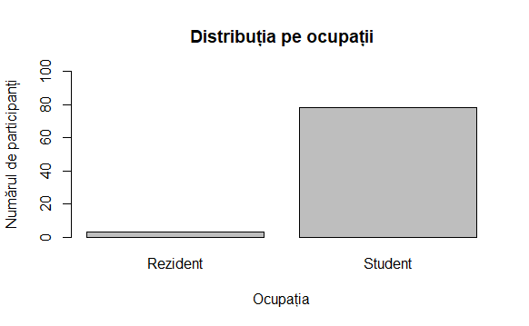

```r
barplot(table(data$position),
        names.arg = c("Rezident", "Student"),
        main = "Distribuția pe ocupații",
        xlab = "Ocupația",
        ylab = "Numărul de participanți",
        ylim = c(0,100))
```

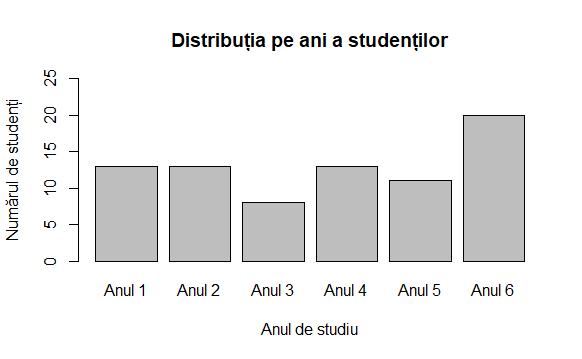

```r
student_year <- table(data$year[ data$year != 0])
barplot(student_year,
        names.arg = c("Anul 1", "Anul 2", "Anul 3", "Anul 4", "Anul 5", "Anul 6"),
        main = "Distribuția pe ani a studenților",
        xlab = "Anul de studiu",
        ylab = "Numărul de studenți",
        ylim = c(0,25)
        )
```

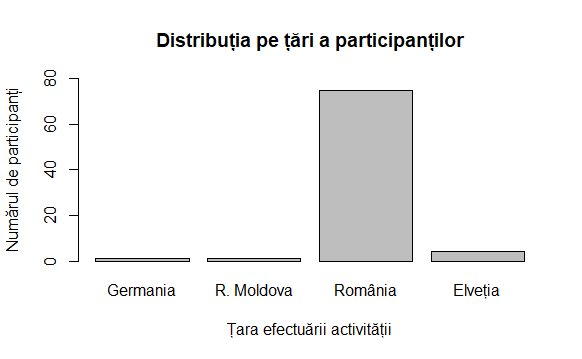

```r
barplot(table(data$country),
        names.arg = c("Germania", "R. Moldova", "România", "Elveția"),
        main = "Distribuția pe țări a participanților",
        xlab = "Țara efectuării activității",
        ylab = "Numărul de participanți",
        ylim = c(0,80)
)
```

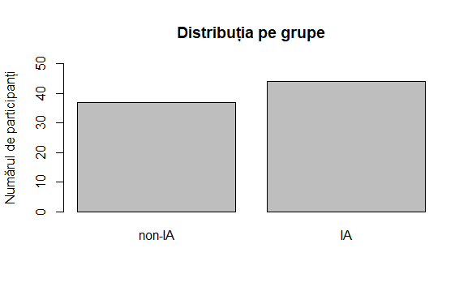

```r
barplot(table(data$category),
        names.arg = c("non-IA", "IA"),
        main = "Distribuția pe grupe",
        #xlab = "Anul de studiu",
        ylab = "Numărul de participanți",
        ylim = c(0,50)
)
```

Concluziile ce pot fi trase după analiza graficelor:

1. Avem un număr relativ apropiat de participanți în cele 2 grupuri de IA și non-IA
2. Doar România este reprezentată suficient ca țară
3. Doar grupul studenților este suficient reprezentat

Se vor crea 2 grupe separate în baza variabilei ”category” (grupul IA și non-IA). Se vor elimina coloanele corespunzătoare variabilelor categoriale. Se vor păstra doar coloanele ce conțin clasificarea imaginilor.

```r
# grupul IA
ai_data <- data[data$category == TRUE, !names(data) %in% c("country", "year", "position", "category")]
glimpse(ai_data)
```

```
Rows: 44
Columns: 10
$ q1  <int> 2, 2, 1, 1, 1, 2, 2, 2, 2, 3, 3, 2, 3, 2, 2, 2, 1, 2, 3…
$ q2  <int> 3, 1, 2, 1, 3, 1, 1, 2, 2, 1, 1, 1, 1, 1, 1, 3, 1, 1, 2…
$ q3  <int> 2, 4, 3, 3, 1, 1, 3, 3, 3, 3, 3, 3, 3, 3, 3, 3, 2, 3, 1…
$ q4  <int> 4, 2, 1, 2, 2, 2, 2, 3, 3, 3, 2, 2, 2, 2, 2, 2, 3, 2, 3…
$ q5  <int> 3, 3, 1, 4, 1, 3, 3, 1, 1, 2, 3, 1, 3, 1, 3, 3, 1, 1, 2…
$ q6  <int> 1, 4, 4, 4, 4, 3, 4, 4, 4, 4, 4, 4, 3, 4, 3, 4, 4, 4, 4…
$ q7  <int> 3, 4, 4, 2, 3, 3, 3, 3, 3, 3, 2, 2, 3, 2, 3, 3, 3, 2, 2…
$ q8  <int> 3, 2, 3, 3, 4, 2, 3, 3, 3, 3, 3, 2, 2, 3, 2, 4, 2, 2, 3…
$ q9  <int> 3, 1, 3, 2, 3, 1, 2, 3, 3, 1, 3, 3, 3, 1, 1, 3, 3, 1, 3…
$ q10 <int> 4, 3, 4, 4, 4, 1, 4, 4, 4, 4, 3, 4, 3, 4, 4, 3, 4, 4, 4…
```

```r
# Sunt 44 de participanti in grupul AI

# grupul non-IA
non_ai_data <- data[data$category == FALSE, !names(data) %in% c("country", "year", "position", "category")]
glimpse(non_ai_data)
```

```
Rows: 37
Columns: 10
$ q1  <int> 1, 2, 1, 3, 1, 2, 2, 1, 2, 3, 2, 2, 1, 2, 3, 4, 1, 2, 3…
$ q2  <int> 3, 1, 3, 1, 1, 4, 1, 3, 2, 3, 3, 1, 3, 1, 1, 2, 2, 4, 4…
$ q3  <int> 2, 3, 4, 2, 3, 3, 3, 2, 1, 2, 3, 3, 3, 1, 3, 4, 4, 1, 2…
$ q4  <int> 2, 2, 3, 4, 1, 2, 3, 2, 2, 2, 2, 2, 1, 2, 3, 1, 3, 1, 1…
$ q5  <int> 1, 1, 3, 3, 2, 1, 1, 1, 2, 1, 1, 1, 1, 1, 1, 2, 2, 2, 1…
$ q6  <int> 3, 3, 1, 2, 4, 2, 4, 4, 3, 4, 4, 3, 2, 2, 2, 3, 4, 3, 4…
$ q7  <int> 1, 2, 3, 2, 3, 4, 3, 2, 1, 2, 2, 3, 2, 1, 2, 3, 4, 1, 3…
$ q8  <int> 4, 3, 2, 2, 2, 2, 2, 2, 2, 3, 3, 2, 2, 2, 3, 2, 4, 4, 1…
$ q9  <int> 2, 1, 3, 1, 3, 2, 2, 1, 2, 1, 1, 1, 3, 2, 2, 3, 2, 1, 1…
$ q10 <int> 1, 1, 3, 4, 4, 3, 4, 4, 2, 4, 4, 4, 4, 4, 1, 4, 3, 2, 4…
```

Pentru cuantificarea variabilității interoperator se va folosi Fleiss Kappa. Limbajul R are o funcție pentru calcularea acestui paramentru (kappam.fleiss). Aceasta întoarce mai multe valori pe lângă valoarea propriu-zisă, valori de care nu e nevoie. Mai jos e o funcție care selectează și întoarce doar valoarea Fleiss Kappa.

```r
compute_kappa <- function(ratings_matrix) {
  kappa_result <- kappam.fleiss(ratings_matrix)
  return(kappa_result$value)
}
```

Funcția compute_kappa cere o matrice, astfel încât imaginile sa fie rânduri, iar răspunsurile participantilor să fie coloane, invers de ce există acum. E nevoie de transpoziția matricei inițiale.

Se va calcula Fleiss Kappa pentru grupul IA.

```r
ratings_ai <- t(as.matrix(ai_data))
kappa_ai <- compute_kappa(ratings_ai)
kappa_ai
```

[output not shown]

Se va calcula Fleiss Kappa pentru grupul non-IA.

```r
ratings_non_ai <- t(as.matrix(non_ai_data))
kappa_non_ai <- compute_kappa(ratings_non_ai)
kappa_non_ai
```

[output not shown]

Se va calcula diferența Fleiss Kappa între cele 2 grupuri.

```r
kappa_difference <- kappa_ai - kappa_non_ai
kappa_difference
```

[output not shown]

Astfel Fleiss Kappa în grupul IA este mai mare decât în grupul non-IA. Mai departe se va încerca să se demonstreze că acest rezultat este semnificativ statistic. În acest scop se va utiliza procedeul Bootstrap, deoarece Fleiss Kappa nu are o distribuție de eșantionare cunoscută.

Pentru implementarea bootstrap vom utiliza funcția boot. Ea are nevoie de următoarele argumente: 1. data - datele utilizate 2. statistic - funcția utilizată pentru calcularea parametrului dorit 3. R - numărul de repetiții

Funcția folosită pentru argumentul ”statistic” al funcției boot. Ea primește ca argument datele introduse și un vector cu indici pentru formarea noului grup. Pentru acest grup se calculează un Fleiss Kappa nou.

```r
boot_kappa <- function(data, indices) {
  sampled_data <- data[indices, ] # se formează grupul nou folosind indicii

  # Se calculează Fleiss Kappa
  kappa <- compute_kappa(t(sampled_data))
  return (kappa)
}
```

Implementarea bootstrap pentru grupul IA.

```r
# Bootstrap pentru grupul IA
boot_kappa1 <- boot(data = ai_data, statistic = boot_kappa, R = 20000)
# Intervalul de încredere pentru distribuția obținută
boot.ci(boot_kappa1, conf = 0.99, type = c("perc"))
```

[output not shown]

Implementarea bootstrap pentru grupul non-IA.

```r
# Bootstrap pentru grupul non-AI
boot_kappa0 <- boot(data = non_ai_data, statistic = boot_kappa, R = 20000)
# Intervalul de incredere
boot.ci(boot_kappa0, conf = 0.99, type = c("perc"))
```

[output not shown]

Histogramele valorilor obținute din cele 2 proceduri bootstrap.

```r
hist(boot_kappa1$t,
     breaks = 50,
     col = "skyblue",
     main = "Histograma valorilor Fleiss Kappa(FK) pentru grupul IA \n și non-IA obținute prin metoda Bootstrap",
     xlab = "Fleiss Kappa",
     ylab = "Frecvența valorii",
     ylim = c(0, 2000),
     xlim = c(0, 0.4)
     )
hist(boot_kappa0$t,
     breaks = 50,
     col = "orange",
     add = TRUE,
)
legend("topright",
       legend = c("FK în grupul non-IA", "FK în grupul IA"),
       fill = c("orange", "skyblue")
)
```

[output not shown]

Vizual se poate observa că intersecția lor este minimă

Histograma diferențelor valorilor din cele 2 grupuri

```r
hist(boot_kappa1$t - boot_kappa0$t,
     breaks = 50,
     col = "forestgreen",
     main = "Histograma diferențelor Fleiss Kappa \n între cele 2 grupuri",
     xlab = "Fleiss Kappa IA  - Fleiss Kappa non-IA",
     ylab = "Frecvența valorii",
     Xlim = c(0, 0.4),
     ylim = c(0,1500)
     )
```

[output not shown]

Se va calcula intervalul de încredere 99% pentru această distribuție (one tailed test, adică se vor lua în considerare valorile cuprinse între percentila 1 și 100). Ipoteza alternativă va presupune că intervenția IA crește Fleiss Kappa/ scade variabilitatea interoperator.

k1 = Fleiss Kappa în grupul IA

k0 = Fleiss Kappa în grupul non-IA

Ipoteza nulă: matematic, k1 - k0 <= 0. În cuvinte, Fleiss Kappa în grupul IA este mai mic sau egal cu cel din grupul non-IA.

Ipoteza alternativă: matematic k1 - k0 > 0. În cuvinte, Fleiss Kappa în grupul IA este mai mare decât în grupul non-IA.

```r
quantile(boot_kappa1$t - boot_kappa0$t, probs = c(0.01, 1))
```

[output not shown]

Intervalul de încredere de 99% one-tailed nu îl conține pe 0. **În concluzie se poate respinge ipoteza nulă.**

Grupul fără sugestii greșite este un subgrup al grupului AI, dar fără imaginile 5 și 10 unde IA a sugerat gradele greșite ale clasificării Outerbridge modificate. Se va analiza cum variază Fleiss Kappa și între aceste 2 grupuri.

```r
errorless_ai_data <- ai_data[ , !names(ai_data) %in% c("q5", "q10")]
glimpse(errorless_ai_data)
```

[output not shown]

Bootstrap pentru grupul fără sugestii greșite.

```r
boot_kappa_errorless <- boot(data = errorless_ai_data, statistic = boot_kappa, R = 20000)
boot.ci(boot_kappa_errorless, conf = 0.99, type = c("perc"))
```

[output not shown]

Histogramele suprapuse ale valorilor Fleiss Kappa obținute prin bootstrap pentru grupul cu sugestii greșite și cel fără sugestii greșite

```r
hist(boot_kappa1$t,
     breaks = 50,
     col = "skyblue",
     main = "Histograma valorilor FK pentru grupul IA cu sugestii greșite \n și grupul IA fără sugestii greșite",
     xlab = "Fleiss Kappa",
     ylab = "Frecvența valorii",
     ylim = c(0, 2000),
     xlim = c(0.1, 0.4)
)
hist(boot_kappa_errorless$t,
     breaks = 50,
     col = "red",
     main = "Histograma valorilor Fleiss Kappa(FK) pentru grupul IA \n și non-IA obținute prin metoda Bootstrap",
     #xlab = "Fleiss Kappa",
     #ylab = "Frecvența valorii",
     #ylim = c(0, 2000),
     #xlim = c(0.1, 0.5),
     add = TRUE
)
legend("topright",
       legend = c("FK în grupul IA cu sugestii greșite", "FK în grupul IA fără sugestii greșite"),
       fill = c("skyblue", "red")
)
```

[output not shown]

Vizual se poate observa că intersecția celor 2 histograme este semnificativă.

Histograma diferențelor valorilor din cele 2 grupuri

```r
# Histograma diferentelor
hist(boot_kappa_errorless$t - boot_kappa1$t,
     breaks = 50,
     col = "orange",
     main = "Histograma diferențelor FK dintre grupul IA\n fără sugestii greșite și cu sugestii greșite",
     xlab = "Fleiss Kappa IA fără sugestii greșite  - Fleiss Kappa IA cu sugestii greșite",
     ylab = "Frecvența valorii",
     Xlim = c(-0.2, 0.2),
     ylim = c(0,2000)
)
```

[output not shown]

În acest caz se va face un interrval de încredere de 99% (two tailed test), pentru că nu există dovezi puternice care să sugere în ce direție va merge Fleiss Kappa în acest nou grup.

k2 = Fleiss Kappa în grupul IA fără sugestii greșite

k1 = Fleiss Kappa în grupul IA

Ipoteza nulă: matematic, k2 - k1 = 0. În cuvinte, nu există o diferență semnificativă statistic a Fleiss Kappa între cele 2 grupuri.

Ipoteza alternativă: matematic k2 - k1 != 0. În cuvinte, există o diferență semnificativă a Fleiss Kappa între cele 2 grupuri.

```r
quantile(boot_kappa_errorless$t - boot_kappa1$t, probs = c(0.005, 0.995))
```

[output not shown]

**Intervalul de încredere de 99% îl conține pe 0, astfel nu se poate respinge ipoteza nulă.**